# Nonstationary Extremes

Lecture 15

February 27, 2026

# Review

## Modeling Extremes

**Values with a very low probability of occurring**, not necessarily high-impact events (which don’t have to be rare!).

1. “Block” extremes, *e.g.* annual maxima (**block maxima**)
2. Values which exceed a certain threshold (**peaks over threshold**)

## Return Levels and Periods

The **$T$-year return level** is the value expected to be observed **on average** once every $T$ years.

The **return period** of an extreme value is the inverse of the exceedance probability.

**Example**: The 100-year return period has an exceedance probability of 1%, *e.g.* the 0.99 quantile.

Return levels are associated with the analogous return period.

## Generalized Extreme Values

Block maxima $Y_n = \max \{X_1, \ldots, X_n \}$ are modeled using **Generalized Extreme Value** distributions: $GEV(\mu, \sigma, \xi)$.

For a GEV, the $T$-year return level is the $1 - 1/T$ quantile.

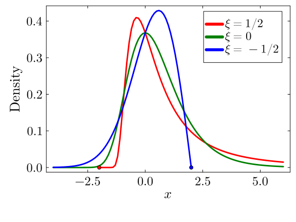

Figure 1: Shape of the GEV distribution with different choices of $\xi$.

```julia
p1 = plot(-2:0.1:6, GeneralizedExtremeValue(0, 1, 0.5), linewidth=3, color=:red, label=L"$\xi = 1/2$", lw=3)
plot!(-4:0.1:6, GeneralizedExtremeValue(0, 1, 0), linewidth=3, color=:green, label=L"$\xi = 0$", lw=3)
plot!(-4:0.1:2, GeneralizedExtremeValue(0, 1, -0.5), linewidth=3, color=:blue, label=L"$\xi = -1/2$", lw=3)
scatter!((-2, 0), color=:red, label=:false)
scatter!((2, 0), color=:blue, label=:false)
ylabel!("Density")
xlabel!(L"$x$")
plot!(size=(600, 450))
```

## Generalized Pareto Distributions

Peaks over a threshold $u$ are modeled using **Generalized Pareto Distribution**: $GPD(\mu, \sigma, \xi)$.

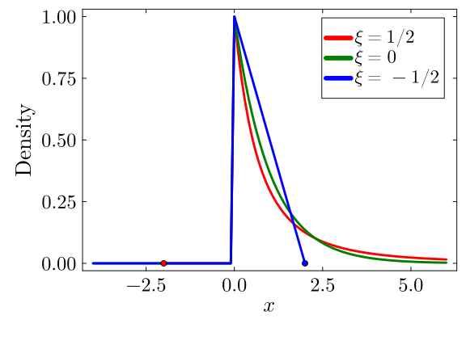

Figure 2: Shape of the GPD distribution with different choices of $\xi$.

```julia
p1 = plot(-2:0.1:6, GeneralizedPareto(0, 1, 0.5), linewidth=3, color=:red, label=L"$\xi = 1/2$", left_margin=5mm, bottom_margin=10mm)
plot!(-4:0.1:6, GeneralizedPareto(0, 1, 0), linewidth=3, color=:green, label=L"$\xi = 0$")
plot!(-4:0.1:2, GeneralizedPareto(0, 1, -0.5), linewidth=3, color=:blue, label=L"$\xi = -1/2$")
scatter!((-2, 0), color=:red, label=:false)
scatter!((2, 0), color=:blue, label=:false)
ylabel!("Density")
xlabel!(L"$x$")
plot!(size=(600, 450))
```

## Example Data

```julia
# load SF tide gauge data
# read in data and get annual maxima
function load_data(fname)
    date_format = DateFormat("yyyy-mm-dd HH:MM:SS")
    # This uses the DataFramesMeta.jl package, which makes it easy to string together commands to load and process data
    df = @chain fname begin
        CSV.read(DataFrame; header=false)
        rename("Column1" => "year", "Column2" => "month", "Column3" => "day", "Column4" => "hour", "Column5" => "gauge")
        # need to reformat the decimal date in the data file
        @transform :datetime = DateTime.(:year, :month, :day, :hour)
        # replace -99999 with missing
        @transform :gauge = ifelse.(abs.(:gauge) .>= 9999, missing, :gauge)
        select(:datetime, :gauge)
    end
    return df
end

d_sf = load_data("data/surge/h551.csv")

## plot data
p1 = plot(
    d_sf.datetime[year.(d_sf.datetime) .== 2000],
    d_sf.gauge[year.(d_sf.datetime) .== 2000] / 1000;
    xlabel="Date",
    ylabel="Tide Level (m)",
    label=false,
    marker=:circle,
    markersize=2
)
```

[figure not shown]

Figure 3: Annual surge data from the San Francisco, CA tide gauge.

## Example: Detrended Data

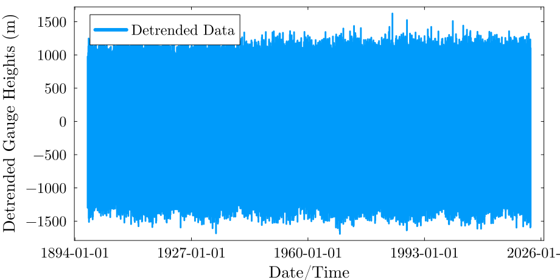

```julia
# detrend the data to remove the effects of sea-level rise and seasonal dynamics
ma_length = 366
ma_offset = Int(floor(ma_length/2))
moving_average(series,n) = [mean(@view series[i-n:i+n]) for i in n+1:length(series)-n]
dat_ma = DataFrame(datetime=d_sf.datetime[ma_offset+1:end-ma_offset], residual=d_sf.gauge[ma_offset+1:end-ma_offset] .- moving_average(d_sf.gauge, ma_offset))

# group data by year and compute the annual maxima
dat_ma = dropmissing(dat_ma) # drop missing data

plot(dat_ma.datetime, dat_ma.residual; ylabel="Detrended Gauge Heights (m)", label="Detrended Data", linewidth=3, legend=:topleft,  xlabel="Date/Time", bottom_margin=5mm, left_margin=5mm, right_margin=5mm)
```

## Declustering

A GPD models conditional exceedances **assuming they are independent realizations.**

But events which result in clustered exceedances (heat waves, TCs) don’t result in independent exceedances.

## Extremal Index

The most common is the **extremal index** $\theta(u)$, which measures the inter-exceedance time for a given threshold $u$.

$$0 \leq \theta(u) \leq 1,$$

where $\theta(u) = 1$ means independence and $\theta(u) = 0$ means the entire dataset is one cluster.

## Computing the Extremal Index

This estimator is taken from Ferro & Segers (2003).

Let $N = \sum_{i=1}^n \mathbb{I}(X_i > u)$ be the total number of exceedances.

Denote by $1 \leq S_1 < \ldots < S_N \leq n$ the exceedance times.

Then the inter-exceedance times are
$$T_i = S_{i+1} - S_i, \quad 1 \leq i \leq N-1.$$

## Computing the Extremal Index

$$\hat{\theta}(u) = \frac{2\left(\sum_{i=1}^{N-1} T_i\right)^2}{(N-1)\sum_{i=1}^{N-1}T_i^2}$$

```julia
# find total number of exceedances and exceedance times
thresh = 1.0
dat_ma.residual = dat_ma.residual ./ 1000 # convert to m
S = findall(dat_ma.residual .> thresh)
N = length(S)
T = diff(S) # get difference between adjacent exceedances
θ = 2 * sum(T)^2 / ((N-1) * sum(T.^2)) # extremal index
```

For the SF tide gauge data and $u=1.0 \text{m}$, we get an extremal index ($\theta(u)$) of 0.24 and a declustering time ($1/\theta(u)$) of 4.0 hours.

## Mapping Data To Clusters

```julia
# cluster data points which occur within period
function assign_cluster(dat, period)
    cluster_index = 1
    clusters = zeros(Int, length(dat))
    for i in 1:length(dat)
        if clusters[i] == 0
            clusters[findall(abs.(dat .- dat[i]) .<= period)] .= cluster_index
            cluster_index += 1
        end
    end
    return clusters
end

# cluster exceedances that occur within a four-hour window
# @transform is a macro from DataFramesMeta.jl which adds a new column based on a data transformation
dat_exceed = dat_ma[dat_ma.residual .> thresh, :]
dat_exceed = @transform dat_exceed :cluster = assign_cluster(:datetime, Dates.Hour(4))
# find maximum value within cluster
dat_decluster = combine(dat_exceed -> dat_exceed[argmax(dat_exceed.residual), :],
    groupby(dat_exceed, :cluster))
dat_decluster
```

# Generalized Pareto-Poisson Processes

## But What About Exceedance Frequency?

The GPD fit gives a distribution for how extreme threshold exceedances are when they occur.

But how often do they occur?

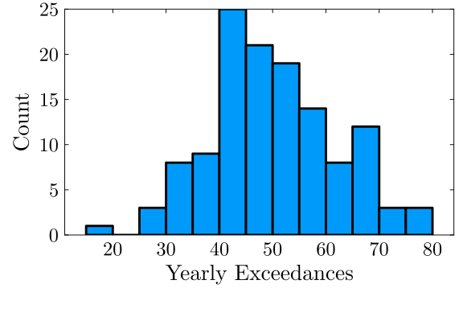

Figure 5: histogram of number of exceedances in each year

```julia
# add column with years of occurrence
dat_decluster = @transform dat_decluster :year = Dates.year.(dat_decluster.datetime)
# group by year and add up occurrences
exceed_counts = combine(groupby(dat_decluster, :year), nrow => :count)
delete!(exceed_counts, nrow(exceed_counts)) # including 2023 will bias the count estimate
p = histogram(exceed_counts.count, legend=:false,
    xlabel="Yearly Exceedances",
    ylabel="Count",
    left_margin=5mm,
    bottom_margin=10mm
)
plot!(size=(600, 400))
```

## Poisson - Generalized Pareto Process

Model the number of new exceedances with a Poisson distribution

$$n \sim \text{Poisson}(\lambda_u),$$

Then, for each $i=1, \ldots, n$, sample
$$X_i \sim \text{GeneralizedPareto}(u, \sigma, \xi).$$

## Poisson - Generalized Pareto Process Return Levels

Then the return level for return period $m$ years can be obtained by solving the quantile equation (see Coles (2001) for details):

$$\text{RL}_m = \begin{cases}u + \frac{\sigma}{\xi} \left((m\lambda_u)^\xi - 1\right) & \text{if}\ \xi \neq 0 \\ u + \sigma \log(m\lambda_u) & \text{if}\ \xi = 0.\end{cases}$$

## Poisson-GPP Example

Question: What is the 100-year return period of the SF data?

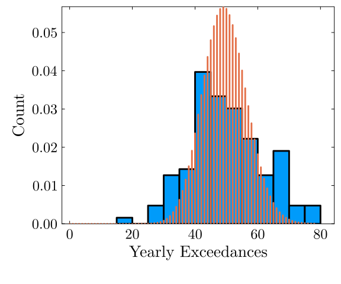

Figure 6: Histogram of number of exceedances in each year with Poisson fit

```julia
# fit GPD
init_θ = [1.0, 1.0]
low_bds = [0.0, -Inf]
up_bds = [Inf, Inf]
gpd_lik(θ) = -sum(logpdf(GeneralizedPareto(0.0, θ[1], θ[2]), dat_decluster.residual .- thresh))
θ_mle = Optim.optimize(gpd_lik, low_bds, up_bds, init_θ).minimizer
count_dist = fit(Poisson, exceed_counts.count)
λ = params(count_dist)[1]

p = histogram(exceed_counts.count, legend=:false,
    xlabel="Yearly Exceedances",
    ylabel="Count",
    normalize=:pdf,
    left_margin=5mm,
    bottom_margin=10mm
)
plot!(size=(600, 500))
plot!(p, count_dist)
```

## Poisson-GPP Example

Poisson: $\lambda =$ 50.0

GPD parameters:

- $\mu = 0$ (fixed)
- $\sigma =$ 0.11
- $\xi =$ -0.17

$$\begin{align*}
\text{RL}_{\text{100}} &= 1 + \frac{\sigma}{\xi} \left((m\lambda)^\xi - 1\right) \\
&= 1 - \frac{0.11}{0.17}\left((100 * 50)^{-0.17} - 1\right) \\
&\approx 1.5 \text{m}
\end{align*}$$

# Nonstationary Extremes

## What is Nonstationarity?

**Nonstationarity**: extremes are not fixed in place, but can become more or less common over time.

[figure not shown]

Nonstationary Example

Source: [Keggenhoff (2015)](https://www.researchgate.net/publication/289954180_Temperature_extremes_over_Georgia_changes_patterns_and_driving_forces)

## Nonstationary GEVs

Suppose block maxima can change with the block (*e.g.* climate change).

$$Y_i \sim GEV(\mu(x_i), \sigma(x_i), \xi(x_i))$$

Common to use generalized linear framework, *e.g.*

$$Y_i \sim GEV(\mu_0 + \mu_1 x_i, \exp(\sigma_0 + \sigma_1 x_i), \xi_0 + \xi_1 x_i)$$

## Be Careful with Nonstationary GEVs

- GEV parameters are already subject to large uncertainties; nonstationarity makes this worse.
- **Be particularly careful with non-stationary $\xi$ (shape).**
- Most common approach: only treat $\mu$ as non-stationary,
  $$Y_i \sim GEV(\mu_0 + \mu_1 x_i, \sigma, \xi)$$

## Nonstationary Return Levels

No non-conditional return periods since distribution depends on $x$.

First specify a covariate value $x$, then can calculate return levels based on that value.

For example: what are 100-year return levels of temperatures in 2020, 2050, and 2100?

## Nonstationary POT

Non-stationarity could influence either the Poisson (how many exceedances occur each year) or GPD (when exceedances occur how are they distributed)?

Often simplest to use a Poisson GLM:

$$\lambda_t = \text{Poisson}(\lambda_0 + \lambda_1 x_t)$$

and let the GPD be stationary.

## Nonstationary Return Levels

Then the $m$-year return level associated with covariate $x_t$ becomes

$$\text{RL}_m = \begin{cases}u + \frac{\sigma}{\xi} \left((m(\lambda_0 + \lambda_1 x_t))^\xi - 1\right) & \text{if}\ \xi \neq 0 \\ u + \sigma \log(m(\lambda_0 + \lambda_1 x_t)) & \text{if}\ \xi = 0.\end{cases}$$

## Nonstationary Example

We might ask how the SF tide extremes depend on the Pacific Decadal Oscillation (PDO).

$y_t \sim \text{GEV}(\mu_0 + \mu_1 \text{PDO}_t, \sigma, \xi)$

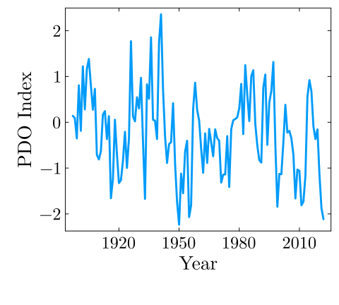

Figure 7

```julia
function load_pdo(fname)
    # This uses the DataFramesMeta.jl package, which makes it easy to string together commands to load and process data
    df = CSV.read(fname, DataFrame, delim=" ", ignorerepeated=true, header=2)
    # take yearly average
    @transform!(df, :PDO = mean(AsTable(names(df)[2:13])))
    @select!(df, $[:Year, :PDO])
    @rsubset!(df, :Year != 2023)
    return df
end

pdo = load_pdo("data/surge/ersst.v5.pdo.dat")
# get maxima
dat_annmax = combine(dat_ma -> dat_ma[argmax(dat_ma.residual), :], groupby(transform(dat_ma, :datetime => x->year.(x)), :datetime_function))
delete!(dat_annmax, nrow(dat_annmax)) # delete 2023; haven't seen much of that year yet
rename!(dat_annmax, :datetime_function => :Year)
select!(dat_annmax, [:Year, :residual])

# subset for years that match the tide gauge data
years = dat_annmax[!, :Year]
@rsubset!(pdo, :Year in years)

plot(pdo.Year, pdo.PDO, xlabel="Year", ylabel="PDO Index", lw=3, label=false, size=(500, 450))
```

## Fitting The Model

```julia
function gev_nonstat_loglik(p, y, pdo)
    μ₀, μ₁, σ, ξ = p
    μ = μ₀ .+ μ₁ .* pdo
    ll = sum(logpdf.(GeneralizedExtremeValue.(μ, σ, ξ), y))
    return ll
end

lb = [-40.0, -1.0, 0.1, -1.0]
ub = [40.0, 1.0, 10.0, 1.0]
x₀ = [10.0, 0.5, 5.0, 0.0]
optim_out = Optim.optimize(p -> -gev_nonstat_loglik(p, dat_annmax.residual, pdo.PDO), lb, ub, x₀)
θ_nonstat = optim_out.minimizer
@show round.(θ_nonstat; digits=1);
```

```
round.(θ_nonstat; digits = 1) = [1.3, -0.0, 0.1, -0.2]
```

# Key Points and Upcoming Schedule

## Key Points

- Peaks Over Thresholds usually modeled with a Generalized Pareto-Poisson process
- Return level calculations can be complicated
- Nonstationary extremes are a form of GLM
- Be careful about which parameters you make nonstationary

## Upcoming Schedule

**Next Week**: Model Assessment and Comparison

# References

## References

Coles, S. (2001). *An Introduction to Statistical Modeling of Extreme Values*. London: Springer-Verlag London.

Ferro, C. A. T., & Segers, J. (2003). Inference for clusters of extreme values. *J. R. Stat. Soc. Series B Stat. Methodol.*, *65*, 545–556. https://doi.org/10.1111/1467-9868.00401